# CDSeq: a complete deconvolution method using sequencing data

# Introduction

CDSeq is a complete deconvolution method using sequencing data. Simply put, CDSeq takes bulk RNA-Seq read counts data as input and estimates the cell-type-specific gene expression profiles (csGEPs) and sample-specific cell-type proportions (SSP) simultaneously.

# Quick start

The minimum inputs for CDSeq are: bulk RNAseq read counts, number of cell types in the mixtures (a scalar or a vector), number of Markov chain Monte Carlo (MCMC) iterations. Set *cpu_number = 1* to avoid using more cpus in this simple example.

```r
result<-CDSeq(bulk_data =  mixtureGEP,
              cell_type_number = 6,
              mcmc_iterations = 1000,
              cpu_number=1)
```

Check out the details about input and output in the following.

# Usage

## Input

[output not shown]

## Ouput

[output not shown]

# Installation

You could install CDSeq from Github by running the following

```r
install_github("kkang7/CDSeq_R_Package")
```

# Examples

## When the number of cell types is a scalar

```r
library(CDSeq)
library(Seurat)
library(ggplot2)
library(ggpubr)
library(dplyr)
```

The following code runs **CDSeq** using synthetic mixtures comes with the R package. The *mixtureGEP* consists of 40 samples with 500 genes. These *in silico* mixtures are generated using six pure cell lines and random generated mixing proportions. **CDSeq** takes *mixtureGEP* as input and outputs the estimates of cell-type-specific gene expressions and sample-specific cell-type proportions. When *refGEP* is provided, CDSeq will assign the identities of those estimated cell types by comparing the GEP of estimated cell types with the GEP of *refGEP*. If *refGEP* is not provided, the estimated cell types will remain anonymous. The other way to annotate CDSeq-estimated cell types is to use single cell RNAseq data.

```r
result1<-CDSeq(bulk_data =  mixtureGEP,
               cell_type_number = 6,
               mcmc_iterations = 2000,
               gene_length = as.vector(gene_length),
               reference_gep = refGEP,  # gene expression profile of pure cell lines
               cpu_number = 1)
```

The output *result1* is a list containing multiple entities as listed in Output. When *cell_type_number* is a scalar, **CDSeq** will only return the following values.

```r
ls(result1)
```

```
#> [1] "cellTypeAssignSplit"  "cell_type_assignment" "estGEP"
#> [4] "estProp"              "gibbsRunningTime"     "parameters"
#> [7] "processIDs"
```

We can compare the CDSeq-estimated cell-type-specific GEPs with the ground truth.

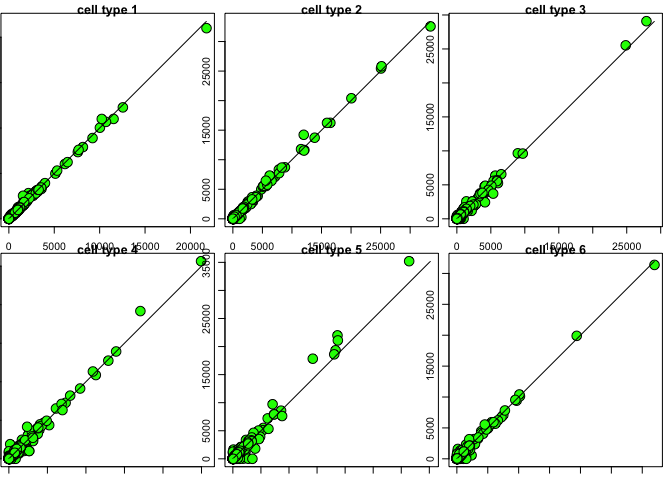

```r
trueGEP <- true_GEP_rpkm[,result1$cell_type_assignment]
.pardefault <- par()
par(mar=c(4,3,1,1), mfrow=c(2,3),mai = c(.1, .01, 0.1, 0.1), pty="s")
for (i in 1:6) {
  max_v <- max(c(result1$estGEP[,i], trueGEP[,i]))
  plot(result1$estGEP[,i],
       trueGEP[,i],
       xlab = "CDSeq-estimated GEPs",
       ylab = "True GEPs",
       pch = 21,
       bg = 'green',
       cex=2,
       xlim = c(0, max_v),
       ylim = c(0,max_v),
       main = paste0("cell type ",i))
  lines(c(0,max_v),c(0,max_v), type = "l")
}
```

```r
par(mar = .pardefault$mar, mfrow = .pardefault$mfrow, mai=.pardefault$mai, pty=.pardefault$pty)
```

We then compare the CDSeq-estimated cell type proportions with group truth.

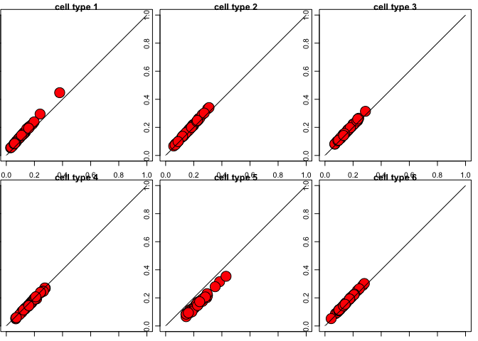

```r
trueProp <- true_prop_cell[result1$cell_type_assignment,]
.pardefault <- par()
par(mar=c(4,3,1,1), mfrow=c(2,3),mai = c(.1, .01, 0.1, 0.1), pty="s")
for (i in 1:6) {
    plot(result1$estProp[i,],
         trueProp[i,],
         pch = 21,
         cex = 3,
         bg='red',
         xlab = "CDSeq-estimated proportions",
         ylab = "True proportions",
         xlim = c(0,1),
         ylim = c(0,1),
         main = paste0("cell type ",i))
    lines(c(0,1),c(0,1), type = "l")
}
```

```r
par(mar = .pardefault$mar, mfrow = .pardefault$mfrow, mai=.pardefault$mai, pty=.pardefault$pty)
```

For this dataset and given parameter settings, CDSeq took this much amount of time to finish:

```r
result1$gibbsRunningTime
```

```
#>     user   system  elapsed
#> 2292.907    2.416 2295.437
```

## When the number of cell types is a vector

The *cell_type_number* can also be a vector which contains different integer values. CDSeq will perform estimation for each integer in the vector and estimate the number of cell types in the mixtures. For example, one can set *cell_type_number = 2:10* as follows, and CDSeq will estimate the most likely number of cell types from 2 to 10.

```r
result2<-CDSeq(bulk_data =  mixtureGEP,
              cell_type_number = 2:10,
              mcmc_iterations = 2000,
              dilution_factor = 1,
              block_number = 1,
              gene_length = as.vector(gene_length),
              reference_gep = refGEP, # gene expression profile of pure cell lines
              cpu_number = 9, # use multiple cores to save time. Set the cpu_number = length(cell_type_number) if there is enough cores.
              print_progress_msg_to_file = 0)
```

CDSeq will automatically estimate the number of cell types from the *cell_type_number* vector (2:10 in our example) and return the corresponding estimate in *estGEP* and *estProp* and it will keep all the estimations for the different values in *cell_type_number* in *est_all*. Check out output for details.

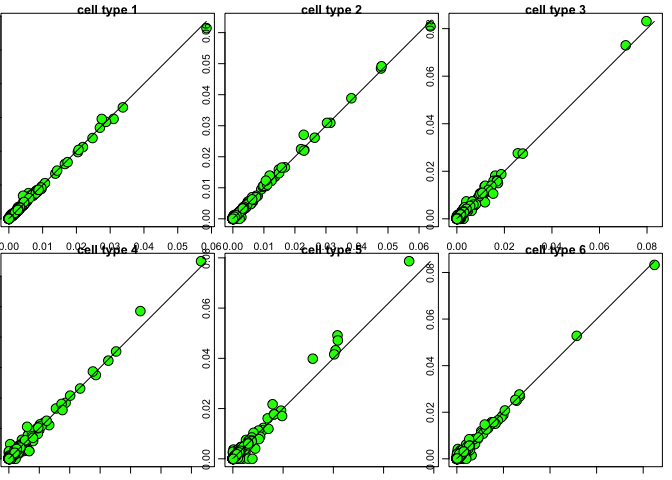

```r
trueGEP <- true_GEP_gene[,result2$cell_type_assignment]
.pardefault <- par()
par(mar=c(4,3,1,1), mfrow=c(2,3),mai = c(.1, .01, 0.1, 0.1),  pty="s")
for (i in 1:6) {
  max_v <- max(c(result2$estGEP[,i], trueGEP[,i]))
  plot(result2$estGEP[,i],
       trueGEP[,i],
       xlab = "CDSeq-estimated GEPs",
       ylab = "True GEPs",
       pch = 21,
       bg = 'green',
       cex=2,
       xlim = c(0, max_v),
       ylim = c(0,max_v),
       main = paste0("cell type ",i))
  lines(c(0,max_v),c(0,max_v), type = "l")
}
```

```r
par(mar = .pardefault$mar, mfrow = .pardefault$mfrow, mai=.pardefault$mai, pty=.pardefault$pty)
```

Similarly, we can compare the CDSeq-estimated cell type proportions with ground truth.

[figure not shown]

```r
trueProp <- true_prop_cell[result2$cell_type_assignment,]
.pardefault <- par()
par(mar=c(4,3,1,1), mfrow=c(2,3),mai = c(.1, .01, 0.1, 0.1),  pty="s")
for (i in 1:6) {
    plot(result2$estProp[i,],
         trueProp[i,],
         pch = 21,
         cex = 3,
         bg='red',
         xlab = "CDSeq-estimated proportions",
         ylab = "True proportions",
         xlim = c(0,1),
         ylim = c(0,1),
         main = paste0("cell type ",i))
    lines(c(0,1),c(0,1), type = "l")
}
```

```r
par(mar = .pardefault$mar, mfrow = .pardefault$mfrow, mai=.pardefault$mai, pty=.pardefault$pty)
```

CDSeq estimates the number of cell types in the bulk samples using log posterior values. You can plot the log posterior values as follows. In this example, the max log posterior value happens at 6, therefore, CDSeq will guess that the number of different cell types in the bulk samples is 6 (which is exactly the number of distinct cell types we used for generating this *in silico* mixtures).

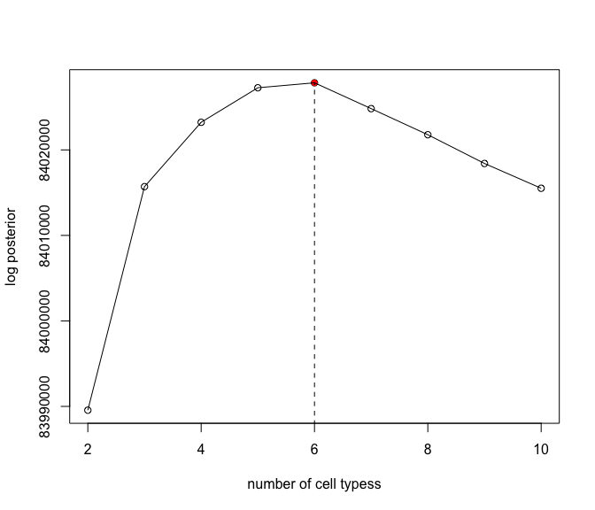

```r
lgpst <- rep(0,9)
for (i in 1:9) {
  lgpst[i] <- result2$est_all[[i]]$lgpst
}
plot(2:10,lgpst,xlab = "number of cell typess", ylab = "log posterior")
points(6,lgpst[5],pch=16,col="red")
lines(2:10, lgpst)
lines(c(6,6),c(0,lgpst[5]),lty=2)
```

## Use dilution factor to speed up CDSeq

To speed up CDSeq, you can use *dilution_factor*. Set *dilution_factor* equal to *N*, CDSeq will require *N* times less computation time. The cost is that using dilution factor will lose information in the bulk samples. In practice, one can first use a large value for *dilution_factor* and estimate how much time will be required for running CDSeq. For example, if setting *dilution_factor=1000* takes CDSeq 1 minute to finish, then setting *dilution_factor=1* will roughly take CDSeq 1000 minutes to finish. Depending on the available computational power and time, one can adjust the value of *dilution_factor* to the affordably miminum value.

## Reduce-Recover strategy for speeding up

We provide another option to speed up CDSeq.The idea of Reduce-Recover is to randomly sample multiple subsets of genes and perform deconvolution on these subsets of genes in parallel and combine the estimations from these subsets and take the average as the final estimates.

To use this feature, you need to set values for *block_number* and *gene_subset_size*.

```r
result3<-CDSeq(bulk_data =  mixtureGEP,
              cell_type_number = 6,
              mcmc_iterations = 2000,
              dilution_factor = 1,
              block_number = 10,
              gene_subset_size = 100,
              gene_length = as.vector(gene_length),
              reference_gep = refGEP,
              cpu_number = 10,
              print_progress_msg_to_file = 0)
```

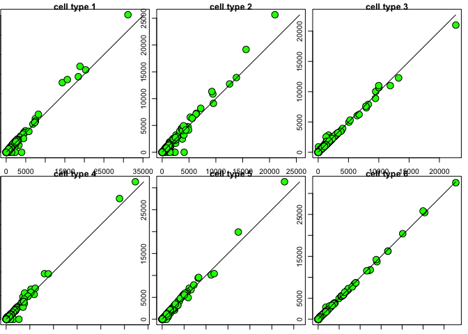

```r
trueGEP <- true_GEP_rpkm[,result3$cell_type_assignment]
.pardefault <- par()
par(mar=c(4,3,1,1), mfrow=c(2,3),mai = c(.1, .01, 0.1, 0.1),  pty="s")
for (i in 1:6) {
  max_v <- max(c(result3$estGEP[,i], trueGEP[,i]))
  plot(result3$estGEP[,i],
       trueGEP[,i],
       xlab = "CDSeq-estimated GEPs",
       ylab = "True GEPs",
       pch = 21,
       bg = 'green',
       cex=2,
       xlim = c(0, max_v),
       ylim = c(0,max_v),
       main = paste0("cell type ",i))
  lines(c(0,max_v),c(0,max_v), type = "l")
}
```

```r
par(mar = .pardefault$mar, mfrow = .pardefault$mfrow, mai=.pardefault$mai, pty=.pardefault$pty)
```

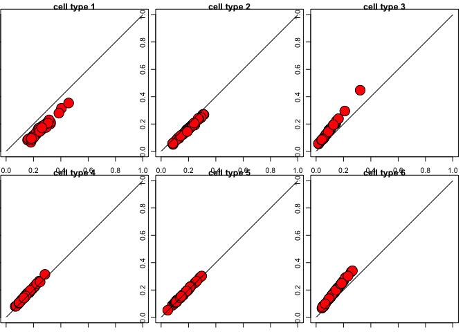

```r
trueProp <- true_prop_cell[result3$cell_type_assignment,]
.pardefault <- par()
par(mar=c(4,3,1,1), mfrow=c(2,3),mai = c(.1, .01, 0.1, 0.1),  pty="s")
for (i in 1:6) {
    plot(result3$estProp[i,],
         trueProp[i,],
         pch = 21,
         cex = 3,
         bg='red',
         xlab = "CDSeq-estimated proportions",
         ylab = "True proportions",
         xlim = c(0,1),
         ylim = c(0,1),
         main = paste0("cell type ",i))
    lines(c(0,1),c(0,1), type = "l")
}
```

```r
par(mar = .pardefault$mar, mfrow = .pardefault$mfrow, mai=.pardefault$mai, pty=.pardefault$pty)
```